# Michael Hornsby EDRM 878 Assignment 2 Notebook

Problem Set 3.16

```r
data(blocks)

blocks$Trial <- as.factor(blocks$Trial)
blocks$Shape <- as.factor(blocks$Shape)

summary(blocks)
```

```
     Child        Number           Time        Trial       Shape         Age
 A      : 4   Min.   : 3.00   Min.   :  6.00   1:50   Cube    :50   Min.   :2.420
 B      : 4   1st Qu.: 5.00   1st Qu.: 14.40   2:50   Cylinder:50   1st Qu.:3.670
 C      : 4   Median : 6.00   Median : 20.20                        Median :4.000
 D      : 4   Mean   : 6.82   Mean   : 29.59                        Mean   :4.026
 E      : 4   3rd Qu.: 8.00   3rd Qu.: 35.00                        3rd Qu.:4.580
 F      : 4   Max.   :13.00   Max.   :178.00                        Max.   :5.080
 (Other):76
```

The model I used in 2.18:

```r
anova(lm(Time ~ Shape, data = blocks))
```

```
Analysis of Variance Table

Response: Time
          Df Sum Sq Mean Sq F value   Pr(>F)
Shape      1   5219  5218.6  8.5396 0.004315 **
Residuals 98  59889   611.1
---
Signif. codes:  0 ‘***’ 0.001 ‘**’ 0.01 ‘*’ 0.05 ‘.’ 0.1 ‘ ’ 1
```

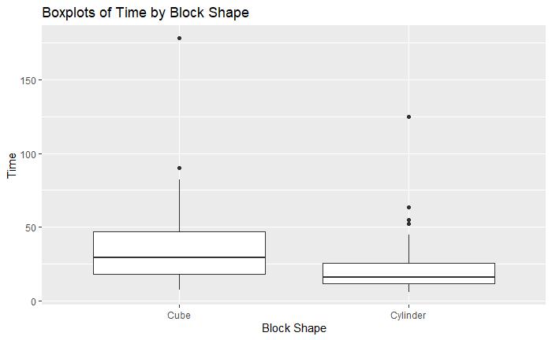

```r
blocks %>%
  ggplot(aes(x = Shape, y = Time)) +
  geom_boxplot() +
  labs(title = "Boxplots of Time by Block Shape",
       x = "Block Shape",
       y = "Time")
```

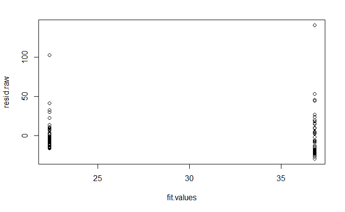

```r
my.model <- lm(Time ~ Shape, data = blocks)

resid.raw <- resid(my.model)

fit.values <- fitted(my.model)

plot(fit.values, resid.raw)
```

Looking at the spread of the boxplots and the outliers present, it isn’t exactly clear I can safely assume equal variance among the groups. This is supported by the plot of raw residuals. The spread of residuals doesn’t look equal among the two groups. One group in the residuals clearly has a larger spread than the other, outliers included.

```r
influence.measures(my.model)
```

```
Influence measures of
     lm(formula = Time ~ Shape, data = blocks) :
```

|  | dfb.1_ | dfb.ShpC | dffit | cov.r | cook.d | hat | inf |
| --- | --- | --- | --- | --- | --- | --- | --- |
| 1 | -3.960075e-02 | 0.0280019621 | -0.0396007546 | 1.0399077 | 7.915664e-04 | 0.02 |  |
| 2 | -1.037504e-01 | 0.0733625948 | -0.1037503765 | 1.0303206 | 5.408148e-03 | 0.02 |  |
| 3 | -1.060929e-01 | 0.0750189737 | -0.1060928501 | 1.0298119 | 5.653719e-03 | 0.02 |  |
| 4 | -8.036957e-02 | 0.0568298664 | -0.0803695678 | 1.0347920 | 3.252317e-03 | 0.02 |  |
| 5 | -4.541639e-02 | 0.0321142378 | -0.0454163906 | 1.0393888 | 1.040872e-03 | 0.02 |  |
| 6 | 1.009002e+00 | -0.7134720625 | 1.0090018671 | 0.4542180 | 3.396246e-01 | 0.02 | * |
| 7 | 3.011386e-02 | -0.0212937118 | 0.0301138561 | 1.0406023 | 4.578869e-04 | 0.02 |  |
| 8 | -9.672802e-02 | 0.0683970412 | -0.0967280233 | 1.0317797 | 4.704150e-03 | 0.02 |  |
| 9 | -1.448853e-01 | 0.1024493556 | -0.1448852681 | 1.0198129 | 1.049281e-02 | 0.02 |  |
| 10 | 1.384616e-02 | -0.0097907105 | 0.0138461555 | 1.0413542 | 9.683686e-05 | 0.02 |  |

[output cut: 90 more lines]

Looking at the influence measures, observations 6 and 76 are cause for concern. Let’s see if this is remedied in our later model.

Let’s look at a qq-plot of time to see if a transformation is needed.

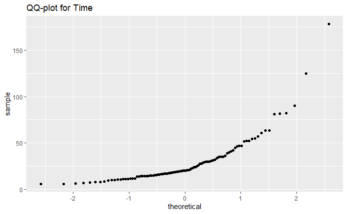

```r
blocks %>%
  ggplot() +
  geom_qq(aes(sample = Time)) +
  labs(title = "QQ-plot for Time")
```

This does show a pretty significant deviation from normality. Let’s look at a boxcox ladder of powers plot.

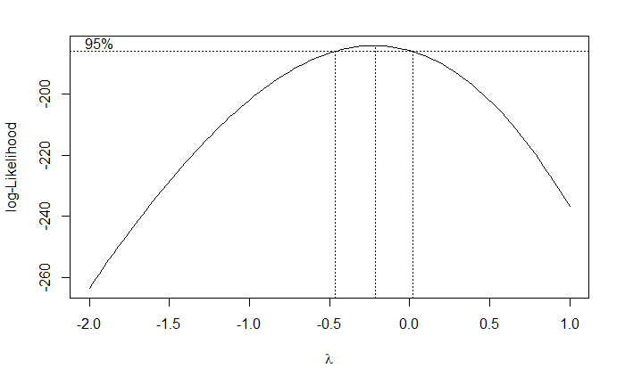

```r
boxcox(Time ~ Shape,
       lambda = seq(-2.00, 1.00, by = .05), data = blocks)
```

Based on this plot. I’m going to look at two transformations. The first will be a log transformation of the Time response. The second will be Time raised to the (-2/5).

```r
blocks$logTime <- log(blocks$Time)
blocks$transTime <- (blocks$Time)^(-2/5)
```

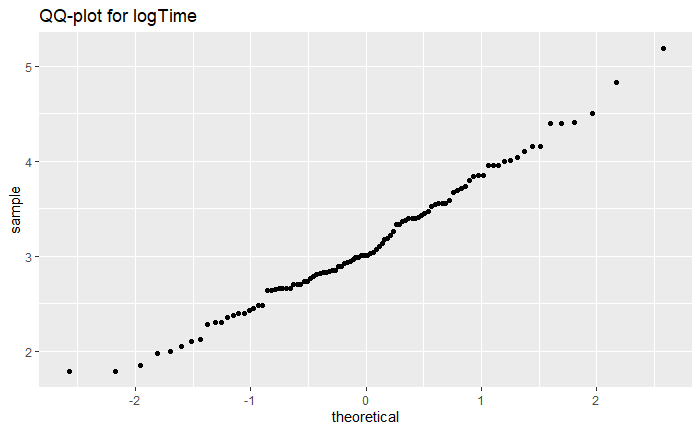

```r
blocks %>%
  ggplot() +
  geom_qq(aes(sample = logTime)) +
  labs(title = "QQ-plot for logTime")
```

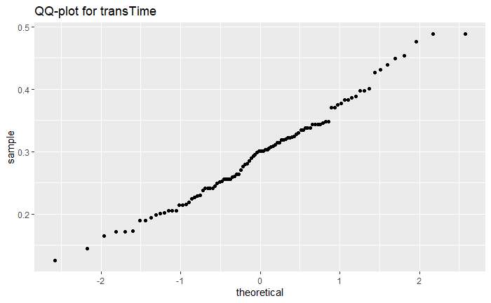

```r
blocks %>%
  ggplot() +
  geom_qq(aes(sample = transTime)) +
  labs(title = "QQ-plot for transTime")
```

Looking at these, I think I am going to stick with the (-2/5) transformation. I know that transformation might be a little tricker to interpret or explain, but I really think the qq-plot looks better.

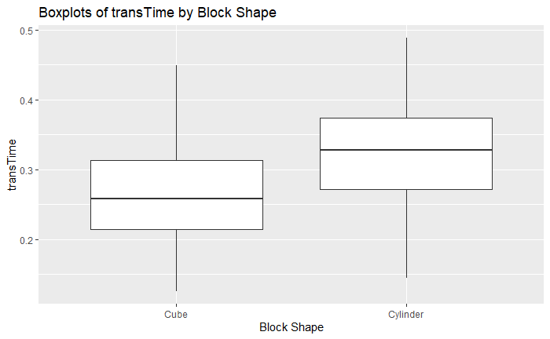

```r
blocks %>%
  ggplot(aes(x = Shape, y = transTime)) +
  geom_boxplot() +
  labs(title = "Boxplots of transTime by Block Shape",
       x = "Block Shape",
       y = "transTime")
```

The boxplots even look like they have equal variance this time!

Let’s look at the new model.

```r
anova(lm(transTime ~ Shape, data = blocks))
```

```
Analysis of Variance Table

Response: transTime
          Df  Sum Sq  Mean Sq F value    Pr(>F)
Shape      1 0.08519 0.085189  15.801 0.0001346 ***
Residuals 98 0.52834 0.005391
---
Signif. codes:  0 ‘***’ 0.001 ‘**’ 0.01 ‘*’ 0.05 ‘.’ 0.1 ‘ ’ 1
```

```r
my.new.model <- lm(transTime ~ Shape, data = blocks)
```

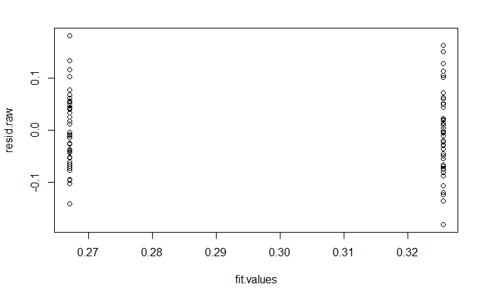

```r
resid.raw <- resid(my.new.model)

fit.values <- fitted(my.new.model)

plot(fit.values, resid.raw)
```

```r
influence.measures(my.new.model)
```

```
Influence measures of
     lm(formula = transTime ~ Shape, data = blocks) :
```

|  | dfb.1_ | dfb.ShpC | dffit | cov.r | cook.d | hat | inf |
| --- | --- | --- | --- | --- | --- | --- | --- |
| 1 | -2.063624e-02 | 0.0145920231 | -0.0206362369 | 1.0411080 | 2.150760e-04 | 0.02 |  |
| 2 | 8.004769e-02 | -0.0566022631 | 0.0800476881 | 1.0348458 | 3.226402e-03 | 0.02 |  |
| 3 | 8.522123e-02 | -0.0602605079 | 0.0852212276 | 1.0339554 | 3.655355e-03 | 0.02 |  |
| 4 | 3.562559e-02 | -0.0251910972 | 0.0356255914 | 1.0402217 | 6.407228e-04 | 0.02 |  |
| 5 | -1.378617e-02 | 0.0097482911 | -0.0137861654 | 1.0413560 | 9.599964e-05 | 0.02 |  |
| 6 | -2.816621e-01 | 0.1991651675 | -0.2816620811 | 0.9628369 | 3.853152e-02 | 0.02 |  |
| 7 | -8.394858e-02 | 0.0593606101 | -0.0839485799 | 1.0341795 | 3.547380e-03 | 0.02 |  |
| 8 | 6.541675e-02 | -0.0462566241 | 0.0654167451 | 1.0370674 | 2.157071e-03 | 0.02 |  |
| 9 | 2.035266e-01 | -0.1439150199 | 0.2035265729 | 0.9992977 | 2.049617e-02 | 0.02 |  |
| 10 | -7.162376e-02 | 0.0506456495 | -0.0716237644 | 1.0361786 | 2.584727e-03 | 0.02 |  |

[output cut: 90 more lines]

The boxplots look as though they have equal variance, the residual plot looks much better and shows a fairly equal spread among the two groups, and the problem of outliers looks to be solved. Surprisingly, it looks as though the transformation of the Time response variable remedied the obvious problems I had. When we look at the influence measures, we have even more observations marked as influential. However, looking at the residuals, I don’t think these are a cause for concern here. Given our sample size and how reasonable everything seems looking at the residuals, I would be extremely hesitant to simply remove any observations with high influence from either model without further information.